# Natural Language Processing - Twitter Analysis

## Problem Statement

### Context

Twitter's massive user base of 330 million monthly active users presents a direct avenue for businesses to connect with a broad audience. However, the vast amount of information on the platform makes it challenging for brands to swiftly detect negative social mentions that may impact their reputation. To tackle this, sentiment analysis has become a crucial tool in social media marketing, enabling businesses to monitor emotions in conversations, understand customer sentiments, and gain insights to stay ahead in their industry.

That's why sentiment analysis/classification, which involves monitoring emotions in conversations on social media platforms, has become a key strategy in social media marketing.

### Objective

The aim of this project is to build a sentimental analysis model that classify the sentiment of tweets into the positive, neutral & negative.

### Data Dictionary

- tweet_id - A unique identifier for each tweet
- airline_sentiment - The sentiment label of the tweet, such as positive, negative, or neutral
- airline_sentiment_confidence - The confidence level associated with the sentiment label
- negativereason - A category indicating the reason for negative sentiment
- negativereason_confidence - The confidence level associated with the negative reason  
  *airline - The airline associated with the tweet
- airline_sentiment_gold - Gold standard sentiment label
- name - The username of the tweet author
- retweet_count - The number of times the tweet has been retweeted
- text - The actual text content of the tweet.
- tweet_coord - Coordinates of the tweet
- tweet_created - The timestamp when the tweet was created
- tweet_location - The location mentioned in the tweet
- user_timezone - The timezone of the tweet author

## Importing necessary libraries

```python
#Libraries to help with reading and manipulating data set
import pandas as pd
import numpy as np

#Display full dataframe information (Non-turncated Text column.)
pd.set_option('display.max_colwidth', None)

# libaries to help with data visualization
import matplotlib.pyplot as plt
import seaborn as sns
# import the figure size for the visualization
from matplotlib import rcParams
#Libraries to help in text prepocessing
import re, string, unicodedata
import contractions
from bs4 import BeautifulSoup

import nltk

nltk.download('stopwords')
nltk.download('punkt')
nltk.download('wordnet')

from nltk.corpus import stopwords
from nltk.tokenize import word_tokenize, sent_tokenize
from nltk.stem.wordnet import WordNetLemmatizer
from sklearn.feature_extraction.text import CountVectorizer, TfidfVectorizer
#Library to split the data
from sklearn.model_selection import train_test_split
#Libraries to print evaluation metrics
from sklearn.metrics import accuracy_score, classification_report, confusion_matrix

from sklearn.model_selection import KFold , StratifiedKFold, cross_val_score

#Library for model building
from sklearn.ensemble import RandomForestClassifier
from sklearn.metrics import classification_report
from sklearn.model_selection import cross_val_score
```

## Loading the dataset

```python
# read the data
data = pd.read_csv('Tweets.csv')
```

## Data Overview

The initial steps to get an overview of any dataset is to:

- Observe the first few rows of the dataset, to check whether the dataset has been loaded properly or not
- Get information about the number of rows and columns in the dataset
- Find out the data types of the columns to ensure that data is stored in the preferred format and the value of each property is as expected.

```python
# Check the first few rows of the dataset
data.head()
```

|  | tweet_id | airline_sentiment | airline_sentiment_confidence | negativereason | negativereason_confidence | airline | airline_sentiment_gold | name | negativereason_gold | retweet_count | text | tweet_coord | tweet_created | tweet_location | user_timezone |
| --- | --- | --- | --- | --- | --- | --- | --- | --- | --- | --- | --- | --- | --- | --- | --- |
| 0 | 570306133677760513 | neutral | 1.0000 | NaN | NaN | Virgin America | NaN | cairdin | NaN | 0 | @VirginAmerica What @dhepburn said. | NaN | 2015-02-24 11:35:52 -0800 | NaN | Eastern Time (US & Canada) |
| 1 | 570301130888122368 | positive | 0.3486 | NaN | 0.0000 | Virgin America | NaN | jnardino | NaN | 0 | @VirginAmerica plus you've added commercials to the experience... tacky. | NaN | 2015-02-24 11:15:59 -0800 | NaN | Pacific Time (US & Canada) |
| 2 | 570301083672813571 | neutral | 0.6837 | NaN | NaN | Virgin America | NaN | yvonnalynn | NaN | 0 | @VirginAmerica I didn't today... Must mean I need to take another trip! | NaN | 2015-02-24 11:15:48 -0800 | Lets Play | Central Time (US & Canada) |
| 3 | 570301031407624196 | negative | 1.0000 | Bad Flight | 0.7033 | Virgin America | NaN | jnardino | NaN | 0 | @VirginAmerica it's really aggressive to blast obnoxious "entertainment" in your guests' faces &amp; they have little recourse | NaN | 2015-02-24 11:15:36 -0800 | NaN | Pacific Time (US & Canada) |
| 4 | 570300817074462722 | negative | 1.0000 | Can't Tell | 1.0000 | Virgin America | NaN | jnardino | NaN | 0 | @VirginAmerica and it's a really big bad thing about it | NaN | 2015-02-24 11:14:45 -0800 | NaN | Pacific Time (US & Canada) |

```python
data.shape
```

```
(14640, 15)
```

- The dataset has 14640 entries and 15 columns.

```python
data.info()
```

```
<class 'pandas.core.frame.DataFrame'>
RangeIndex: 14640 entries, 0 to 14639
Data columns (total 15 columns):
 #   Column                        Non-Null Count  Dtype
---  ------                        --------------  -----
 0   tweet_id                      14640 non-null  int64
 1   airline_sentiment             14640 non-null  object
 2   airline_sentiment_confidence  14640 non-null  float64
 3   negativereason                9178 non-null   object
 4   negativereason_confidence     10522 non-null  float64
 5   airline                       14640 non-null  object
 6   airline_sentiment_gold        40 non-null     object
 7   name                          14640 non-null  object
 8   negativereason_gold           32 non-null     object
 9   retweet_count                 14640 non-null  int64
 10  text                          14640 non-null  object
 11  tweet_coord                   1019 non-null   object
 12  tweet_created                 14640 non-null  object
 13  tweet_location                9907 non-null   object
 14  user_timezone                 9820 non-null   object
dtypes: float64(2), int64(2), object(11)
memory usage: 1.7+ MB
```

- Some columns have missing values, such as 'negativereason,' 'negativereason_confidence,' 'airline_sentiment_gold,' etc.

```python
data.isnull().sum().sort_values(ascending=False)
```

```
negativereason_gold             14608
airline_sentiment_gold          14600
tweet_coord                     13621
negativereason                   5462
user_timezone                    4820
tweet_location                   4733
negativereason_confidence        4118
tweet_id                            0
airline_sentiment                   0
airline_sentiment_confidence        0
airline                             0
name                                0
retweet_count                       0
text                                0
tweet_created                       0
dtype: int64
```

```python
data.describe(include="all").T
```

|  | count | unique | top | freq | mean | std | min | 25% | 50% | 75% | max |
| --- | --- | --- | --- | --- | --- | --- | --- | --- | --- | --- | --- |
| tweet_id | 14640.0 | NaN | NaN | NaN | 569218351767499200.0 | 779111158481835.875 | 567588278875213824.0 | 568559178101439488.0 | 569477857923110912.0 | 569890473289000960.0 | 570310600460525568.0 |
| airline_sentiment | 14640 | 3 | negative | 9178 | NaN | NaN | NaN | NaN | NaN | NaN | NaN |
| airline_sentiment_confidence | 14640.0 | NaN | NaN | NaN | 0.900169 | 0.16283 | 0.335 | 0.6923 | 1.0 | 1.0 | 1.0 |
| negativereason | 9178 | 10 | Customer Service Issue | 2910 | NaN | NaN | NaN | NaN | NaN | NaN | NaN |
| negativereason_confidence | 10522.0 | NaN | NaN | NaN | 0.638298 | 0.33044 | 0.0 | 0.3606 | 0.6706 | 1.0 | 1.0 |
| airline | 14640 | 6 | United | 3822 | NaN | NaN | NaN | NaN | NaN | NaN | NaN |
| airline_sentiment_gold | 40 | 3 | negative | 32 | NaN | NaN | NaN | NaN | NaN | NaN | NaN |
| name | 14640 | 7701 | JetBlueNews | 63 | NaN | NaN | NaN | NaN | NaN | NaN | NaN |
| negativereason_gold | 32 | 13 | Customer Service Issue | 12 | NaN | NaN | NaN | NaN | NaN | NaN | NaN |
| retweet_count | 14640.0 | NaN | NaN | NaN | 0.08265 | 0.745778 | 0.0 | 0.0 | 0.0 | 0.0 | 44.0 |
| text | 14640 | 14427 | @united thanks | 6 | NaN | NaN | NaN | NaN | NaN | NaN | NaN |
| tweet_coord | 1019 | 832 | [0.0, 0.0] | 164 | NaN | NaN | NaN | NaN | NaN | NaN | NaN |
| tweet_created | 14640 | 14247 | 2015-02-24 09:54:34 -0800 | 5 | NaN | NaN | NaN | NaN | NaN | NaN | NaN |
| tweet_location | 9907 | 3081 | Boston, MA | 157 | NaN | NaN | NaN | NaN | NaN | NaN | NaN |
| user_timezone | 9820 | 85 | Eastern Time (US & Canada) | 3744 | NaN | NaN | NaN | NaN | NaN | NaN | NaN |

#### Observations from the statistical summary of the dataset:

**1.tweet_id**:

- The 'tweet_id' column represents unique identifiers for tweets.
- - The dataset has 14640 unique tweets. The mean, standard deviation, and other statistical measures are not particularly meaningful for tweet identifiers.

**2.airline_sentiment**:

- There are three unique sentiments: 'negative,' 'neutral,' and 'positive.'
- The majority of tweets (9178) express a negative sentiment.

**3.airline_sentiment_confidence**:

- The confidence scores for sentiment analysis range from 0.335 to 1.0.
- On average, the model is quite confident in its sentiment predictions, with a mean confidence of approximately 0.900169.

**4.negativereason**:

- There are 10 unique negative reasons for tweets.
- 'Customer Service Issue' is the most frequent negative reason.

**5.negativereason_confidence**:

**6.airline**:

- There are six unique airlines in the dataset.
- 'United' is the most frequent airline.

**7.airline_sentiment_gold**:

- The 'airline_sentiment_gold' column has three unique values, with 'negative' being the most frequent.

**8.name**:

- There are 7,701 unique names in the dataset.
- 'JetBlueNews' is the most frequent name.

**9.negativereason_gold**:

- There are 13 unique negative reasons in the 'negativereason_gold' column.
- 'Customer Service Issue' is the most frequent reason.

**10.retweet_count**:

**11.text**:

- There are 14,427 unique text entries.
- The most frequent text entry is "@united thanks."

**12.tweet_coord**:

- There are 832 unique coordinates in the 'tweet_coord' column, with [0.0, 0.0] being the most frequent.
- Many tweets do not have associated coordinates.

**13.tweet_created**:

- There are 14,247 unique timestamp entries, indicating when tweets were created.
- The timestamp '2015-02-24 09:54:34 -0800' has the highest frequency.

**14.tweet_location**:

- There are 3081 unique locations mentioned in the 'tweet_location' column.
- 'Boston, MA' is the most frequent location.

**15.user_timezone**:

- There are 85 unique timezones mentioned in the 'user_timezone' column.
- 'Eastern Time (US & Canada)' is the most frequent timezone.

## Exploratory Data Analysis

- EDA is an important part of any project involving data.
- It is important to investigate and understand the data better before building a model with it.
- A few questions have been mentioned below which will help you approach the analysis in the right manner and generate insights from the data.
- A thorough analysis of the data, in addition to the questions mentioned below, should be done.

**Questions**:

- What is the percentage of tweets for each airline?
- What is the distribution of sentiments across all the tweets?
- What is the distribution of sentiments for each airline?
- What does the plot of negative reasons indicate?
- How does a wordcloud appear for negative tweets?
- How does a wordcloud appear for positive tweets?
- What are insights observed from EDA?

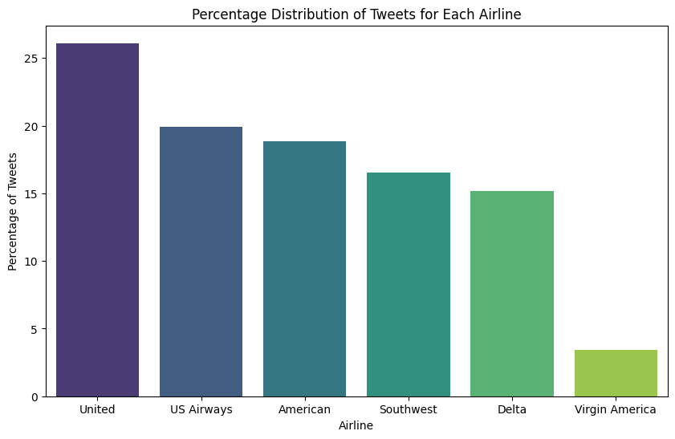

```
Percentage of tweets for each airline:
United            26.106557
US Airways        19.897541
American          18.845628
Southwest         16.530055
Delta             15.177596
Virgin America     3.442623
Name: airline, dtype: float64
```

```python
# Calculate the percentage distribution of tweets for each airline
airline_percentage = data['airline'].value_counts(normalize=True) * 100

# Plot the bar chart
plt.figure(figsize=(10, 6))
sns.barplot(x=airline_percentage.index, y=airline_percentage.values, palette='viridis')
plt.title('Percentage Distribution of Tweets for Each Airline')
plt.xlabel('Airline')
plt.ylabel('Percentage of Tweets')
plt.show()

# Calculate percentage of tweets for each airline
tweets_per_airline = data['airline'].value_counts() / len(data) * 100
print("Percentage of tweets for each airline:")
print(tweets_per_airline)
```

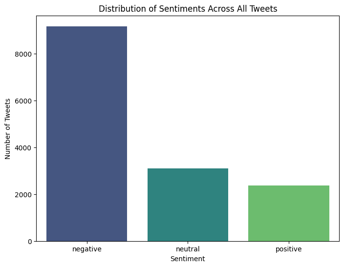

```
Distribution of sentiments across all tweets:
negative    9178
neutral     3099
positive    2363
Name: airline_sentiment, dtype: int64
```

```python
# Get the count of each sentiment
sentiment_counts = data['airline_sentiment'].value_counts()

# Plot the countplot with bars in descending order
plt.figure(figsize=(8, 6))
sns.countplot(x='airline_sentiment', data=data, order=sentiment_counts.index, palette='viridis')
plt.title('Distribution of Sentiments Across All Tweets')
plt.xlabel('Sentiment')
plt.ylabel('Number of Tweets')
plt.show()

# Distribution of sentiments across all tweets
sentiment_distribution = data['airline_sentiment'].value_counts()
print("Distribution of sentiments across all tweets:")
print(sentiment_distribution)
```

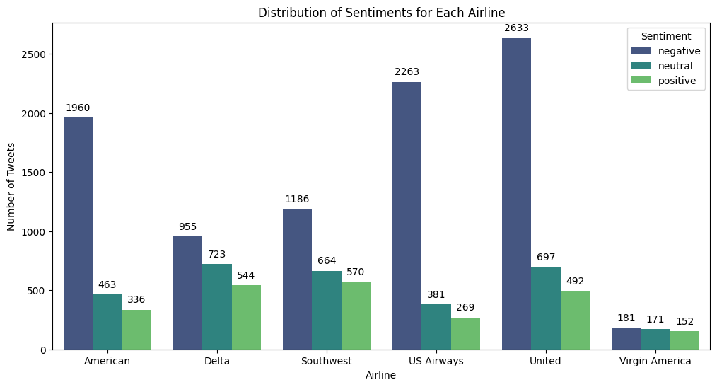

```python
# Create a DataFrame for visualization
airline_sentiment_df = data.groupby(['airline', 'airline_sentiment']).size().unstack().reset_index()
airline_sentiment_df = airline_sentiment_df.melt(id_vars='airline', var_name='sentiment', value_name='count')

# Plot the stacked bar chart with values displayed
plt.figure(figsize=(12, 6))
ax = sns.barplot(x='airline', y='count', hue='sentiment', data=airline_sentiment_df, palette='viridis')

# Display values on top of the bars
for p in ax.patches:
    ax.annotate(f'{p.get_height():.0f}', (p.get_x() + p.get_width() / 2., p.get_height()),
                ha='center', va='center', fontsize=10, color='black', xytext=(0, 10),
                textcoords='offset points')

plt.title('Distribution of Sentiments for Each Airline')
plt.xlabel('Airline')
plt.ylabel('Number of Tweets')
plt.legend(title='Sentiment')
plt.show()
```

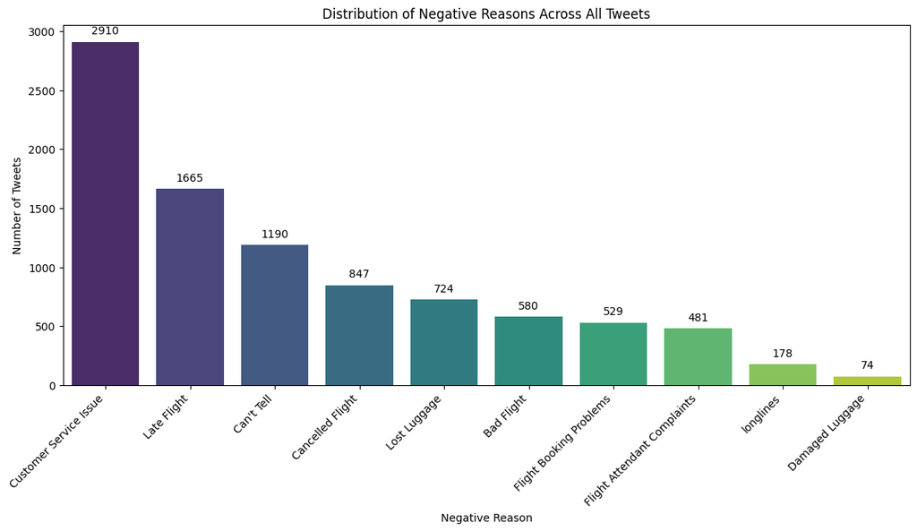

```python
# Plot the countplot for negative reasons with counts displayed
plt.figure(figsize=(14, 6))
ax = sns.countplot(x='negativereason', data=data, order=data['negativereason'].value_counts().index, palette='viridis')

# Display counts on top of the bars
for p in ax.patches:
    ax.annotate(f'{p.get_height():.0f}', (p.get_x() + p.get_width() / 2., p.get_height()),
                ha='center', va='center', fontsize=10, color='black', xytext=(0, 10),
                textcoords='offset points')

plt.title('Distribution of Negative Reasons Across All Tweets')
plt.xlabel('Negative Reason')
plt.ylabel('Number of Tweets')
plt.xticks(rotation=45, ha='right')  # Rotate x-axis labels for better readability
plt.show()
```

- We can see that the most of the negative tweets are due to customer service issue and due to flight delay.

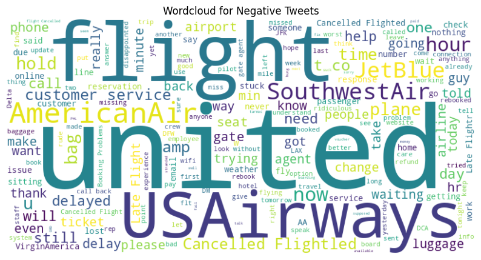

```python
from wordcloud import WordCloud

# Wordcloud for negative tweets
negative_tweets = data[data['airline_sentiment'] == 'negative']['text'].values
negative_wordcloud = WordCloud(width=800, height=400, background_color='white').generate(' '.join(negative_tweets))

plt.figure(figsize=(10, 6))
plt.imshow(negative_wordcloud, interpolation='bilinear')
plt.axis('off')
plt.title('Wordcloud for Negative Tweets')
plt.show()
```

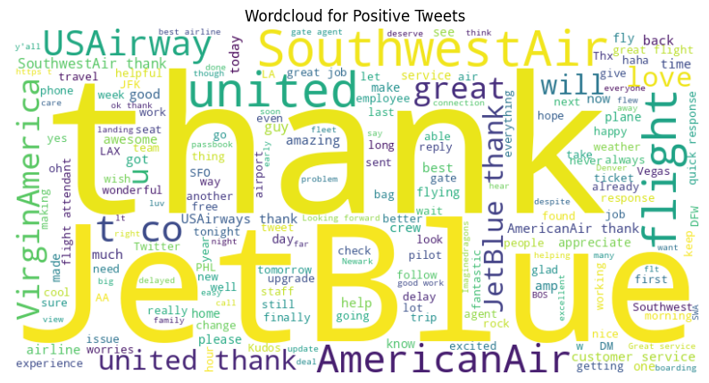

```python
# Wordcloud for positive tweets
positive_tweets = data[data['airline_sentiment'] == 'positive']['text'].values
positive_wordcloud = WordCloud(width=800, height=400, background_color='white').generate(' '.join(positive_tweets))

plt.figure(figsize=(10, 6))
plt.imshow(positive_wordcloud, interpolation='bilinear')
plt.axis('off')
plt.title('Wordcloud for Positive Tweets')
plt.show()
```

**Insights from EDA**

- Percentage of Tweets per Airline: It Shows the distribution of tweets among different airlines.
- Sentiment Distribution Across All Tweets: It Indicates the overall sentiment distribution (positive, negative, neutral) in the dataset.
- Sentiment Distribution for Each Airline: It Illustrates sentiment distribution per airline, showing how sentiments vary across them.
- Negative Reasons Plot: It Displays the reasons for negative tweets, providing insights into common issues faced by customers.
- Wordclouds: Visual representations of the most frequent words in negative and positive tweets, highlighting common themes or sentiments expressed. These visualizations and analyses offer insights into sentiment distributions, common negative reasons, and the most frequent words used in both negative and positive tweets, enabling a better understanding of customer sentiments towards different airlines.
- We can see negative word cloud represents most of the words like customer service,delay,cancelled flight etc.
- For positive word cloud we can see words like thank,great,good,wonderful etc.

## Data Preparation for Modeling

- Drop all unnecessary columns
- Remove html tags
- Replace contractions in string(e.g. replace I'm --> I am) and so on.\
- Remove numbers
- Tokenization
- To remove Stopwords
- Lemmatized data

```python
# Drop unnecessary columns
columns_to_keep = ['airline_sentiment', 'text']
df = data[columns_to_keep]
```

- We are keeping only the columns that are necessary for our purpose

### Text Cleaning

```python
#remove the html tags
def strip_html(text):
    soup = BeautifulSoup(text, "html.parser")
    return soup.get_text()

#expand the contractions
def replace_contractions(text):
    """Replace contractions in string of text"""
    return contractions.fix(text)

#remove the numericals present in the text
def remove_numbers(text):
  text = re.sub(r'\d+', '', text)
  return text

# remove the url's present in the text
def remove_url(text):
    text = re.sub('http[s]?://(?:[a-zA-Z]|[0-9]|[$-_@.&+]|[!*\(\),]|(?:%[0-9a-fA-F][0-9a-fA-F]))+','',text)
    return text

# remove the mentions in the tweets
def remove_mention(text):
    text = re.sub(r'@\w+','',text)
    return text

def clean_text(text):
    text = strip_html(text)
    text = replace_contractions(text)
    text = remove_numbers(text)
    text = remove_url(text)
    text = remove_mention(text)
    return text
df['text'] = df['text'].apply(lambda x: clean_text(x))
df.head()
```

|  | airline_sentiment | text |
| --- | --- | --- |
| 0 | neutral | What said. |
| 1 | positive | plus you have added commercials to the experience... tacky. |
| 2 | neutral | I did not today... Must mean I need to take another trip! |
| 3 | negative | it is really aggressive to blast obnoxious "entertainment" in your guests' faces & they have little recourse |
| 4 | negative | and it is a really big bad thing about it |

### Tokenization

```python
df['text'] = df.apply(lambda row: nltk.word_tokenize(row['text']), axis=1) # tokenization of data
df.head()
```

|  | airline_sentiment | text |
| --- | --- | --- |
| 0 | neutral | [What, said, .] |
| 1 | positive | [plus, you, have, added, commercials, to, the, experience, ..., tacky, .] |
| 2 | neutral | [I, did, not, today, ..., Must, mean, I, need, to, take, another, trip, !] |
| 3 | negative | [it, is, really, aggressive, to, blast, obnoxious, ``, entertainment, '', in, your, guests, ', faces, &, they, have, little, recourse] |
| 4 | negative | [and, it, is, a, really, big, bad, thing, about, it] |

### Normalize text

```python
stopwords = stopwords.words('english')
custom_remove_list = ['flight']
stopwords = list(set(stopwords)) + custom_remove_list
lemmatizer = WordNetLemmatizer()

# remove the non-ASCII characters
def remove_non_ascii(words):
    """Remove non-ASCII characters from list of tokenized words"""
    new_words = []
    for word in words:
        new_word = unicodedata.normalize('NFKD', word).encode('ascii', 'ignore').decode('utf-8', 'ignore')
        new_words.append(new_word)
    return new_words

# convert all characters to lowercase
def to_lowercase(words):
    """Convert all characters to lowercase from list of tokenized words"""
    new_words = []
    for word in words:
        new_word = word.lower()
        new_words.append(new_word)
    return new_words

# remove the hashtags
def remove_hash(text):
   """Remove hashtags from list of tokenized words"""
   new_words = []
   for word in words:
     new_word = re.sub(r'#\w+','',word)
     if new_word != '':
       new_words.append(new_word)
   return new_words

# remove the punctuations
def remove_punctuation(words):
    """Remove punctuation from list of tokenized words"""
    new_words = []
    for word in words:
        new_word = re.sub(r'[^\w\s]', '', word)
        if new_word != '':
            new_words.append(new_word)
    return new_words

# remove the stop words
def remove_stopwords(words):
    """Remove stop words from list of tokenized words"""
    new_words = []
    for word in words:
        if word not in stopwords:
            new_words.append(word)
    return new_words

# lemmatize the words
def lemmatize_list(words):
    new_words = []
    for word in words:
      new_words.append(lemmatizer.lemmatize(word, pos='v'))
    return new_words

def normalize(words):
    words = remove_non_ascii(words)
    words = to_lowercase(words)
    words = remove_punctuation(words)
    words = remove_stopwords(words)
    words = lemmatize_list(words)
    return ' '.join(words)

df['text'] = df.apply(lambda row: normalize(row['text']), axis=1)
df.head()
```

|  | airline_sentiment | text |
| --- | --- | --- |
| 0 | neutral | say |
| 1 | positive | plus add commercials experience tacky |
| 2 | neutral | today must mean need take another trip |
| 3 | negative | really aggressive blast obnoxious entertainment guests face little recourse |
| 4 | negative | really big bad thing |

## Model Building

### Using countvectorizer

```python
# Initialize CountVectorizer
cv = CountVectorizer(max_features=1000)

# convert text to numbers with CountVectorizer
data_features_count = cv.fit_transform(df['text'])

# convert the data features to array
data_features_count = data_features_count.toarray()
```

```python
# show shape of the feature vector
data_features_count.shape
```

```
(14640, 1000)
```

```python
# split data into training and testing set
X_count = data_features_count
y = df.airline_sentiment
X_train_count, X_test_count, y_train, y_test = train_test_split(X_count, y, test_size=0.25, shuffle=False, random_state=42)
```

```python
# find the optimal number of base learners using k-fold cross-validation (CV)
base_ln = np.arange(100,400,100).tolist()

# train model with k-fold CV
cv_scores = []
for b in base_ln:
    clf = RandomForestClassifier(n_estimators = b)
    scores = cross_val_score(clf, X_train_count, y_train, cv = 5, scoring = 'accuracy')
    cv_scores.append(scores.mean())
```

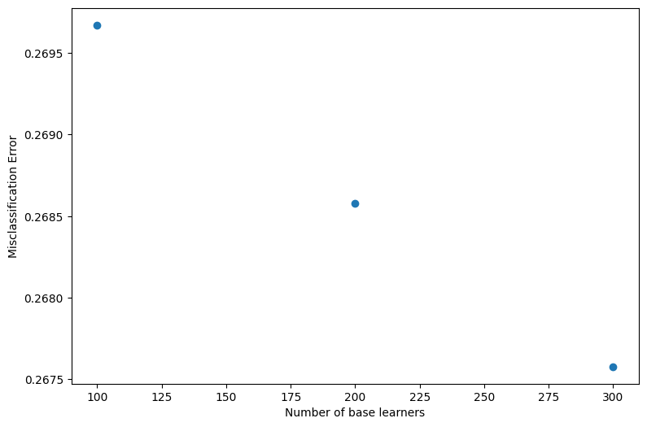

```python
# set figure size
rcParams['figure.figsize'] = 9,6
# plot the error as k-fold increases
error = [1 - x for x in cv_scores]                                              # error corresponds to each number of estimator
optimal_learners = base_ln[error.index(min(error))]                             # optimal number of n_estimator selected by minimum error
plt.scatter(base_ln, error)                                                     # plot number of estimators with corresponding misclassification error
xy = (optimal_learners, min(error))
plt.xlabel("Number of base learners")
plt.ylabel("Misclassification Error")
plt.show()
```

```python
# train the best model
clf_count = RandomForestClassifier(n_estimators = optimal_learners, random_state=42)
clf_count.fit(X_train_count, y_train)
clf_count.score(X_test_count, y_test)
count_predicted = clf_count.predict(X_test_count)
```

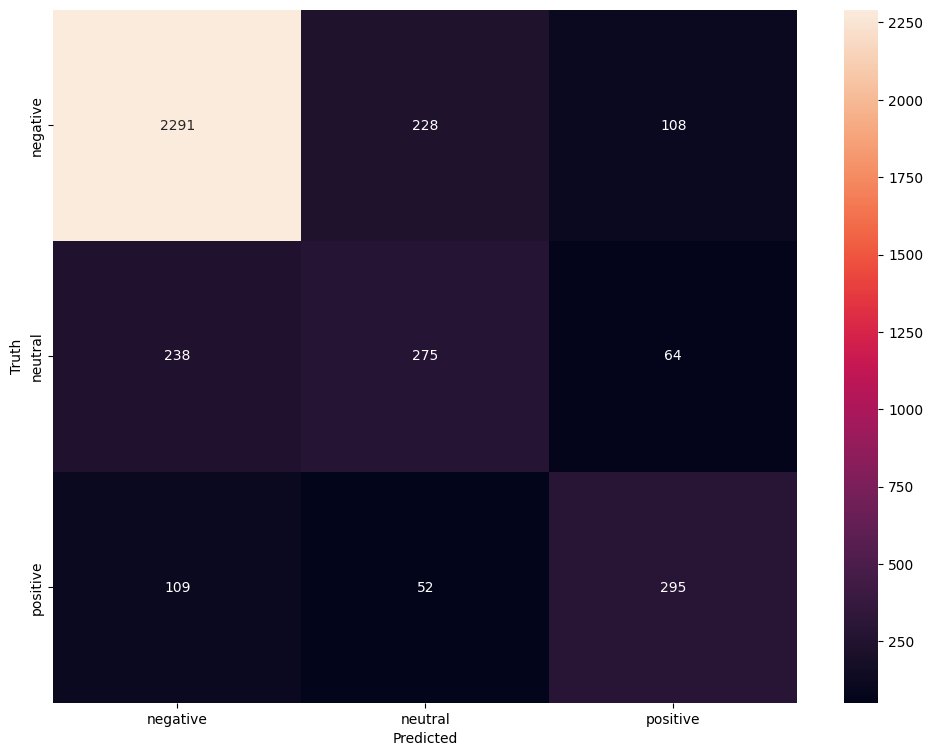

```python
#create confusion matrix for Count Vectorizer
cm_count=confusion_matrix(y_test,count_predicted)

plt.figure(figsize=(12,9))
sns.heatmap(cm_count,annot=True,fmt='d',xticklabels=clf_count.classes_ , yticklabels= clf_count.classes_)
plt.xlabel('Predicted')
plt.ylabel('Truth')
plt.show()
```

- The model is classifying 2,291 out of 2,627 negative tweets correctly (87%), 275 out of 577 neutral tweets correctly (47%), and 295 out of 456 positive tweets correctly (64%)

```python
all_features_count = cv.get_feature_names_out()                              # instantiate the features from the vectorizer
top_features_count=''                                                           # addition of top 40 features into top_feature after training the model
feat=clf_count.feature_importances_
features=np.argsort(feat)[::-1]
for i in features[0:40]:
    top_features_count+=all_features_count[i]
    top_features_count+=', '

top_features_count
```

```
'thank, delay, great, love, hours, hold, awesome, cancel, bag, get, hour, amaze, best, fly, wait, please, would, worst, plane, customer, time, call, service, help, fleek, lose, go, make, never, late, need, still, say, miss, flight, try, luggage, tell, fleet, good, '
```

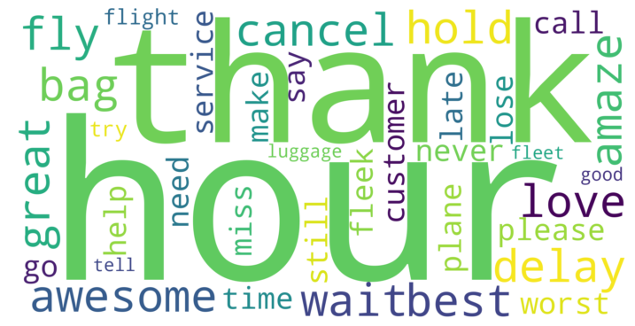

```python
from wordcloud import WordCloud
# create word cloud
wordcloud_count = WordCloud(background_color="white",colormap='viridis',width=2000,
                          height=1000).generate(top_features_count)

# show word cloud
plt.imshow(wordcloud_count, interpolation='bilinear')
plt.figure(1, figsize=(15, 12), frameon='equal')
plt.axis("off")
plt.show()
```

```python
# saving variables for model
y_train_count = y_train
y_test_count = y_test
```

### Using TF-IDF (Term Frequency- Inverse Document Frequency)

```python
# set the max number of features at 1000
tfidf_vec = TfidfVectorizer(max_features=1000)
# convert test to numbers with TfidfVectorizer
data_features_idf = tfidf_vec.fit_transform(df['text'])
# convert the data features to array
data_features_idf = data_features_idf.toarray()
```

```python
# show shape of the feature vector
data_features_idf.shape
```

```
(14640, 1000)
```

```python
# split data into training and testing set
X_idf = data_features_idf
y = df.airline_sentiment
X_train_idf, X_test_idf, y_train, y_test = train_test_split(X_idf, y, test_size=0.25, shuffle=False, random_state=42)
```

```python
# find the optimal number of base learners using k-fold cross-validation (CV)
base_ln = np.arange(100,400,100).tolist()

# train model with k-fold CV
cv_scores = []
for b in base_ln:
    clf = RandomForestClassifier(n_estimators = b)
    scores = cross_val_score(clf, X_train_idf, y_train, cv = 5, scoring = 'accuracy')
    cv_scores.append(scores.mean())
```

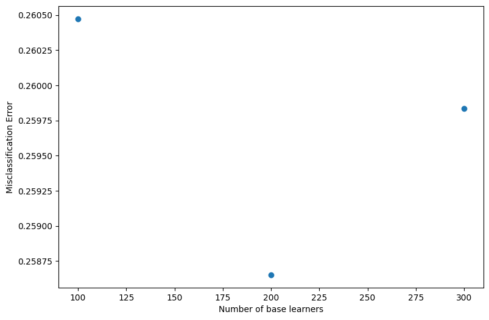

```python
# plot the error as k-fold increases
error = [1 - x for x in cv_scores]                                              # error corresponds to each number of estimator
optimal_learners = base_ln[error.index(min(error))]                             # optimal number of n_estimator selected by minimum error
plt.scatter(base_ln, error)                                                     # plot number of estimators with corresponding misclassification error
xy = (optimal_learners, min(error))
plt.xlabel("Number of base learners")
plt.ylabel("Misclassification Error")
plt.show()
```

```python
# train the best model
clf = RandomForestClassifier(n_estimators = optimal_learners, random_state=42)
clf.fit(X_train_idf, y_train)
clf.score(X_test_idf, y_test)
tf_idf_predicted = clf.predict(X_test_idf)
```

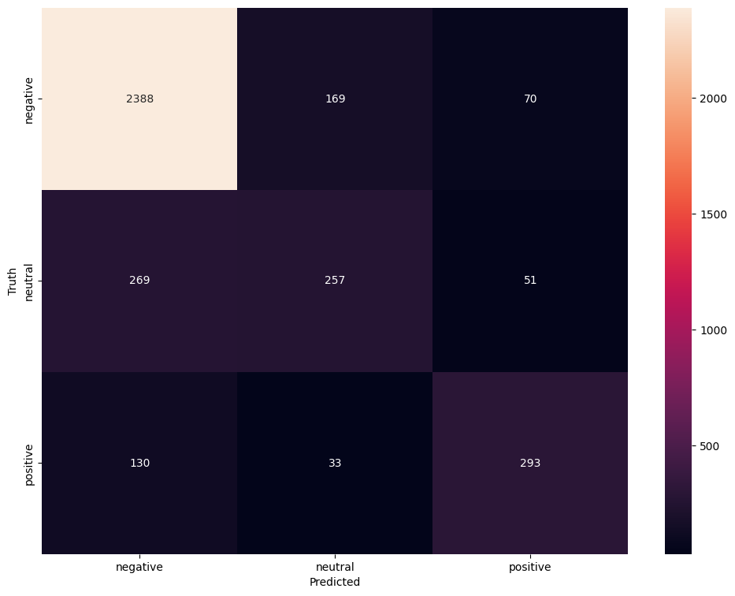

```python
# create confusion matrix for TF-IDF Vectorizer
cm_tfidf=confusion_matrix(y_test , tf_idf_predicted)

plt.figure(figsize=(12,9))
sns.heatmap(cm_tfidf,annot=True,fmt='d',xticklabels=clf.classes_ , yticklabels=clf.classes_)
plt.xlabel('Predicted')
plt.ylabel('Truth')
plt.show()
```

- The model is classifying 2,388 out of 2,627 negative tweets correctly (91%), 257 out of 577 neutral tweets correctly (44%), and 293 out of 456 positive tweets correctly (64%)

```python
all_features = tfidf_vec.get_feature_names_out()                                    # instantiate the features from the vectorizer
top_features=''                                                                 # addition of top 40 features into top_feature after training the model
feat=clf.feature_importances_
features=np.argsort(feat)[::-1]
for i in features[0:40]:
    top_features+=all_features[i]
    top_features+=', '

top_features
```

```
'thank, delay, great, love, hours, hold, cancel, get, awesome, bag, best, amaze, hour, fly, please, fleek, wait, service, would, time, make, follow, plane, fleet, customer, call, flight, good, help, need, dm, know, worst, go, airline, say, never, lose, still, late, '
```

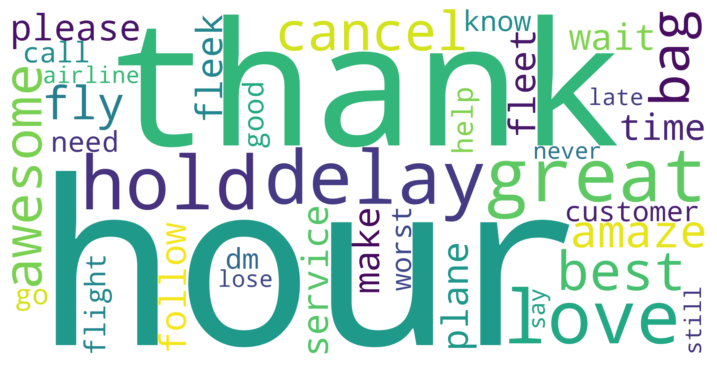

```python
from wordcloud import WordCloud
# create word cloud
wordcloud = WordCloud(background_color="white",colormap='viridis',width=2000,
                          height=1000).generate(top_features)

# show word cloud
plt.imshow(wordcloud, interpolation='bilinear')
plt.figure(1, figsize=(15, 12), frameon='equal')
plt.axis("off")
plt.show()
```

```python
# saving variables for model
y_train_idf = y_train
y_test_idf = y_test
```

### Recurring Neural Network

```python
from tensorflow.keras.preprocessing.text import Tokenizer
from tensorflow.keras.preprocessing.sequence import pad_sequences
from tensorflow.keras.layers import Dense, Input, LSTM, Embedding, Dropout, Activation, Flatten, Bidirectional, BatchNormalization
from tensorflow.keras.models import Model, Sequential
from sklearn.preprocessing import LabelEncoder
```

```python
text_corpus = df.text
labels_corpus = df.airline_sentiment

X_train, X_test, y_train, y_test = train_test_split(text_corpus, labels_corpus, test_size=0.25, random_state=42)
```

```python
# set hyperparameters
num_words=4000
maxlen=1000
```

```python
# vectorize the text samples into a 2D integer tensor
tokenizer = Tokenizer(num_words=num_words, char_level=False)

tokenizer.fit_on_texts(X_train)

sequences_train = tokenizer.texts_to_sequences(X_train)
sequences_test = tokenizer.texts_to_sequences(X_test)

len(sequences_train)
```

```
10980
```

```python
# pad sequences with 0s
X_train = pad_sequences(sequences_train, maxlen=maxlen)
X_test = pad_sequences(sequences_test, maxlen=maxlen)

print('Shape of data tensor:', X_train.shape)
print('Shape of data test tensor:', X_test.shape)
print(type(X_train))
```

```
Shape of data tensor: (10980, 1000)
Shape of data test tensor: (3660, 1000)
<class 'numpy.ndarray'>
```

```python
# encode target variable
label_encoder = LabelEncoder()
y_train_label = label_encoder.fit_transform(y_train)
y_test_label = label_encoder.fit_transform(y_test)
```

### Defining the model

```python
from keras import backend
import tensorflow as tf
backend.clear_session()

# set the seed for random number generators
np.random.seed(42)
import random
random.seed(42)
tf.random.set_seed(42)
```

```python
def create_model(maxlen,num_words,num_categories):

    model = Sequential()

    model.add(Embedding(num_words,output_dim=100,input_length=maxlen,trainable=True))

    model.add(BatchNormalization())

    model.add(Bidirectional(LSTM(100)))

    model.add(Dropout(0.2))

    model.add(Dense(128,activation='relu'))

    model.add(BatchNormalization())

    model.add(Dense(64,activation='relu'))

    model.add(Dropout(0.2))

    model.add(Dense(32,activation='relu'))

    model.add(Dense(num_categories, activation='softmax'))

    model.compile(loss='sparse_categorical_crossentropy',optimizer="adam",metrics=['accuracy'])

    model.summary()
    return model
```

```python
model=create_model(maxlen,num_words,df.airline_sentiment.nunique())
```

```
Model: "sequential"
_________________________________________________________________
 Layer (type)                Output Shape              Param #
=================================================================
 embedding (Embedding)       (None, 1000, 100)         400000

 batch_normalization (Batch  (None, 1000, 100)         400
 Normalization)

 bidirectional (Bidirection  (None, 200)               160800
 al)

 dropout (Dropout)           (None, 200)               0

 dense (Dense)               (None, 128)               25728

 batch_normalization_1 (Bat  (None, 128)               512
 chNormalization)

 dense_1 (Dense)             (None, 64)                8256

 dropout_1 (Dropout)         (None, 64)                0

 dense_2 (Dense)             (None, 32)                2080

 dense_3 (Dense)             (None, 3)                 99

=================================================================
Total params: 597875 (2.28 MB)
Trainable params: 597419 (2.28 MB)
Non-trainable params: 456 (1.78 KB)
_________________________________________________________________
```

```python
history = model.fit(X_train, y_train_label, epochs=5, validation_split=0.25)
```

### Model evaluation on training data

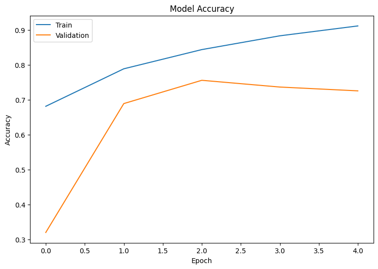

```python
plt.plot(history.history['accuracy'])
plt.plot(history.history['val_accuracy'])
plt.title('Model Accuracy')
plt.ylabel('Accuracy')
plt.xlabel('Epoch')
plt.legend(['Train', 'Validation'], loc='upper left')
plt.show()
```

### Model evaluation on test data

```python
accuracy = model.evaluate(X_test, y_test_label, verbose=2)
```

```
115/115 - 3s - loss: 0.8840 - accuracy: 0.7309 - 3s/epoch - 25ms/step
```

```python
#creating a dictionary to map model predictions to each sentiment
class_dict = {0:'negative',
 1:'neutral',
 2:'positive'}
```

```python
#making predictions on the test data
y_pred_test = model.predict(X_test)

#converting probabilities to class labels
y_pred_test_classes = np.argmax(y_pred_test, axis=1)

#calculating the probability of the predicted class
y_pred_test_max_probas = np.max(y_pred_test, axis=1)
```

```python
#creating a dataframe of model predictions
df1 = pd.DataFrame({"Labels":y_pred_test_classes})

#replacing predictions with sentiments
label_df = df1.replace({"Labels":class_dict})

#converting dataframe to array
y_pred_test_classes = label_df.to_numpy()
```

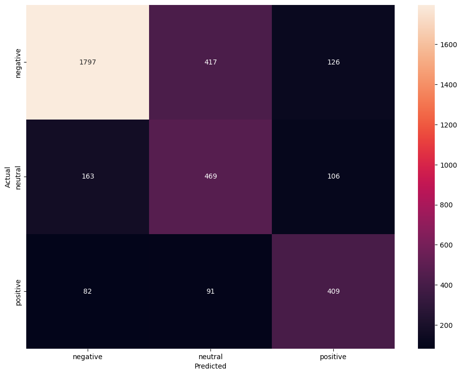

```python
#plotting the heatmap using confusion matrix
cm_rnn = confusion_matrix(y_test, y_pred_test_classes)
plt.figure(figsize=(12,9))
sns.heatmap(cm_rnn, annot=True,  fmt='.0f', xticklabels=clf.classes_, yticklabels=clf.classes_)
plt.ylabel('Actual')
plt.xlabel('Predicted')
plt.show()
```

- The model is classifying 1,797 out of 2,340 negative tweets correctly (77%), 469 out of 738 neutral tweets correctly (63%), and 409 out of 582 positive tweets correctly (70%)

## Summary

```python
# provide a classification report on the Count Vectorizer model
print("Random Forest model trained with Count Vectorizer data")
print(" ")
print(classification_report(y_test_count , count_predicted, target_names = clf.classes_))
print(" ")

# provide a classification report on the TF-IDF Vectorizer model
print("Random Forest model trained with TF-IDF Vectorizer data")
print(" ")
print(classification_report(y_test_idf , tf_idf_predicted, target_names = clf.classes_))
print(" ")

# provide the classification report on the RNN model
print("Recurring Neural Network (RNN) model")
print(" ")
print(classification_report(y_test, y_pred_test_classes))
```

```
Random Forest model trained with Count Vectorizer data

              precision    recall  f1-score   support

    negative       0.87      0.87      0.87      2627
     neutral       0.50      0.48      0.49       577
    positive       0.63      0.65      0.64       456

    accuracy                           0.78      3660
   macro avg       0.67      0.67      0.67      3660
weighted avg       0.78      0.78      0.78      3660


Random Forest model trained with TF-IDF Vectorizer data

              precision    recall  f1-score   support

    negative       0.86      0.91      0.88      2627
     neutral       0.56      0.45      0.50       577
    positive       0.71      0.64      0.67       456

    accuracy                           0.80      3660
   macro avg       0.71      0.67      0.68      3660
weighted avg       0.79      0.80      0.80      3660


Recurring Neural Network (RNN) model

              precision    recall  f1-score   support

    negative       0.88      0.77      0.82      2340
     neutral       0.48      0.64      0.55       738
    positive       0.64      0.70      0.67       582

    accuracy                           0.73      3660
   macro avg       0.67      0.70      0.68      3660
weighted avg       0.76      0.73      0.74      3660
```

**Additional Suggestions:**

1. **Enhanced Customer Engagement:** Airlines can use sentiment analysis results to proactively engage with customers, addressing concerns or acknowledging positive feedback. This approach fosters a stronger connection with the customer base.
2. **Tailored Marketing Strategies:** Companies can Utilize the insights gained from the models to tailor marketing strategies. Focus on promoting aspects of the customer experience that are likely to drive positive sentiments, and address and improve areas associated with negative sentiments.
3. **Continuous Model Monitoring:** Corporations can Regularly monitor and update the classification model to ensure its accuracy over time. As trends and customer sentiments evolve, the model should be adjusted to reflect these changes effectively.
4. **Feedback Loop Implementation:** To Establish a feedback loop where customer interactions, especially responses to social media engagement, are used to continuously refine and improve the sentiment analysis models.
5. **Employee Training:** Train customer-facing staff to effectively handle situations identified through sentiment analysis. This enables a timely and empathetic response to customer concerns, contributing to overall customer satisfaction.

These suggestions aim to leverage the insights gained from the models to not only address negative sentiments but also enhance and improve positive customer experiences, ultimately strengthening the relationship between airlines and their customers by Using NLP technology.